# Final Project

Laia Esquerrà

June 30, 2017

# Exploratory Analysis

Given the data from *Instacart* and the previous analysis we made, we suggest here some further approaches to it.

First of all we’ll analyse the pattern of the last minute purchases. Beforehand, it would make sense that these follow a different pattern than general purchases, being this purchases made during the latter hours of the day directly related to some fast dinner arrangements or similar.

On the other hand, we’ll analyse the last products added to a shopping cart. A first hypothesis in this case could be that those last items are usually not planned beforehand, i.e., they have impulsively been added responding to last minute whims or as a result of the given recommendations from the app.

Finally, we’ll see how regular consumers behave in relation to the rest.

## Last minute purchases

As we’ve previously said, we expect that this last minute purchases, done at late night hours might show a differential behaviour from the rest of the orders.

To analyse this, we’ll select the most ordered products for puchases made after 8pm.

```r
last_hour_txt <- "
SELECT ab.product_id
,   n_orders
,   product_name
FROM (
    SELECT product_id
    ,   COUNT(1) AS n_orders
    FROM (SELECT order_id
          FROM orders_tbl
          WHERE order_hour_of_day > 20) a
      LEFT JOIN order_products__prior_tbl b
      ON a.order_id = b.order_id
    WHERE product_id IS NOT NULL
    GROUP BY product_id
    ORDER BY n_orders DESC
    LIMIT 30) ab
LEFT JOIN (
    SELECT product_id
    ,   product_name
    FROM products_tbl) c
ON ab.product_id = c.product_id
"

(last_hour <-
  dbGetQuery(sc, last_hour_txt))
```

```
##    product_id n_orders                         product_name
## 1       24852    25953                               Banana
## 2       13176    22162               Bag of Organic Bananas
## 3       21137    16731                 Organic Strawberries
## 4       21903    14561                 Organic Baby Spinach
## 5       47209    12229                 Organic Hass Avocado
## 6       47766    10043                      Organic Avocado
## 7       27845     9059                   Organic Whole Milk
## 8       27966     8604                  Organic Raspberries
## 9       16797     8419                         Strawberries
## 10      47626     8347                          Large Lemon
## 11      26209     7910                                Limes
## 12      45007     6737                     Organic Zucchini
## 13      39275     6704                  Organic Blueberries
## 14      22935     6443                 Organic Yellow Onion
```

[output cut: 16 more lines]

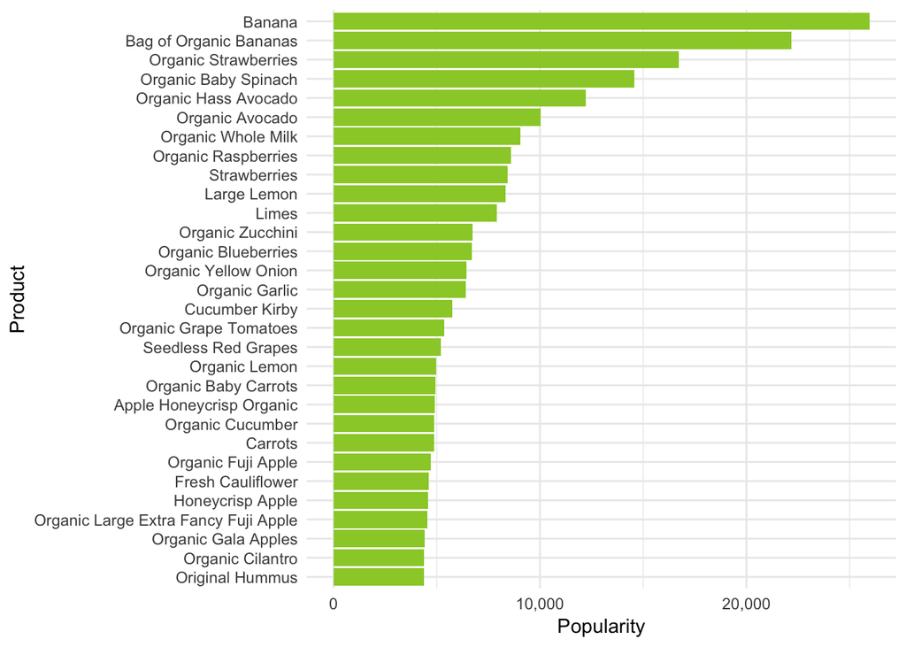

```r
last_hour %>%
  ggplot(
    aes(reorder(product_name, n_orders, function(x) x),
        n_orders)) +
  geom_bar(stat="identity", fill='yellowgreen') +
  coord_flip() +
  scale_y_continuous(label=scales::comma) +
  xlab("Product") +
  ylab(paste("Popularity")) +
  theme_minimal()
```

On the contrary, these purchases same to follow the exact same pattern than the rest, being bananas clearly the most ordered product.

Note that this data comes from an app where customers select groceries online from various retailers and these are delivered by a personal shopper. Therefore, the fact that an order is taken in the evening shows no differential pattern, thus this purchases will probably be delivered the next day. It doesn’t really correspond to a last minute purchase but to customers who make their orders at night when at home.

**Actions** $\to$ If the analysis had given significant results, we could have thought of some discounts or baskets of multiple products which are not usually bought but could actually be usefull to this consumer and would buy them in this case. For example, we could add some paper napkins or disposable plates to offer at a discount price when bought with pizza.

## Last added products

Which are the last added products in a basket? Do they follow a pattern or do they appear to be random and thus, probably unnecessary, resulting from a last minute impulse?

To analyse this we will select those products which, for each order of the first 50 orders, have been the latter one added.

```r
last_prods_txt <- "
SELECT ab.product_id, product_name, COUNT(1) as n
FROM
  (SELECT b.*
  FROM
    (SELECT *
    FROM (SELECT order_id
          ,   LAST_VALUE(add_to_cart_order)  OVER(partition by order_id ORDER BY order_id) AS nmax
          FROM order_products__prior_tbl
          WHERE order_id <= 50) a
    GROUP BY order_id, nmax
    ORDER BY order_id) aa
      LEFT JOIN order_products__prior_tbl AS b
      ON aa.nmax=b.add_to_cart_order
  WHERE aa.order_id=b.order_id
  ORDER BY order_id) ab LEFT JOIN products_tbl c
    ON ab.product_id = c.product_id
GROUP BY ab.product_id, product_name
ORDER BY n DESC
"

(last_prods <-
  dbGetQuery(sc, last_prods_txt))
```

```
##    product_id                                               product_name n
## 1       41897              Clean Day Lavender Scent Room Freshener Spray 1
## 2       43511 Sunrise Grilled Steak and Eggs Canine Cuisine Wet Dog Food 1
## 3        1057                     Basil, Asiago & Pine Nut Pesto Ravioli 1
## 4       31268                                              Sandwich Bags 1
## 5       46175                                      Half Baked® Ice Cream 1
## 6       47766                                            Organic Avocado 1
## 7        9436                                      Organic Vidalia Onion 1
## 8       28199                                           Clementines, Bag 1
## 9       36929                                            Milk, Vitamin D 1
## 10      25952                                      Original Potato Chips 1
## 11      40063                         Gluten Free Chocolate Chip Cookies 1
## 12      34866                                  Chocolate Milk 1% Milkfat 1
## 13      41276                                               Energy Drink 1
## 14      31506                                     Extra Virgin Olive Oil 1
```

[output cut: 31 more lines]

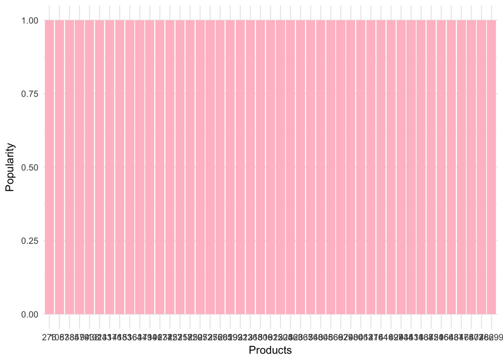

```r
last_prods %>%
  ggplot(
    aes(reorder(product_id, n, function(x) x),
        n)) +
  geom_bar(stat="identity", fill='pink') +
  theme(axis.text.x = element_text(angle = 90)) +
  scale_y_continuous(label=scales::comma) +
  xlab("Products") +
  ylab(paste("Popularity")) +
  theme(axis.text.x = element_text(angle = 90, hjust = 1)) +
  theme_minimal()
```

As we can see there is no particular product which tends to be added at the end, we can analyse though if they all come from some particular department.

**Departments**

Instead of counting which particular products have been selected, here we’ll focus on the department they come from.

```r
last_prods_dpt_txt <- "
SELECT department_id, COUNT(1) as n
FROM
  (SELECT b.*
  FROM
    (SELECT *
    FROM (SELECT order_id
          ,   LAST_VALUE(add_to_cart_order)  OVER(partition by order_id ORDER BY order_id) AS nmax
          FROM order_products__prior_tbl
          WHERE order_id <= 50) a
    GROUP BY order_id, nmax
    ORDER BY order_id) aa
      LEFT JOIN order_products__prior_tbl AS b
      ON aa.nmax=b.add_to_cart_order
  WHERE aa.order_id=b.order_id
  ORDER BY order_id) ab LEFT JOIN products_tbl c
    ON ab.product_id = c.product_id
GROUP BY department_id
ORDER BY n DESC
"

(last_prods_dpt <-
  dbGetQuery(sc, last_prods_dpt_txt))
```

```
##    department_id  n
## 1              4 14
## 2             19  7
## 3             16  4
## 4              1  4
## 5             17  3
## 6              3  3
## 7              7  2
## 8             11  2
## 9             20  2
## 10             8  1
## 11             9  1
## 12            13  1
## 13            14  1
```

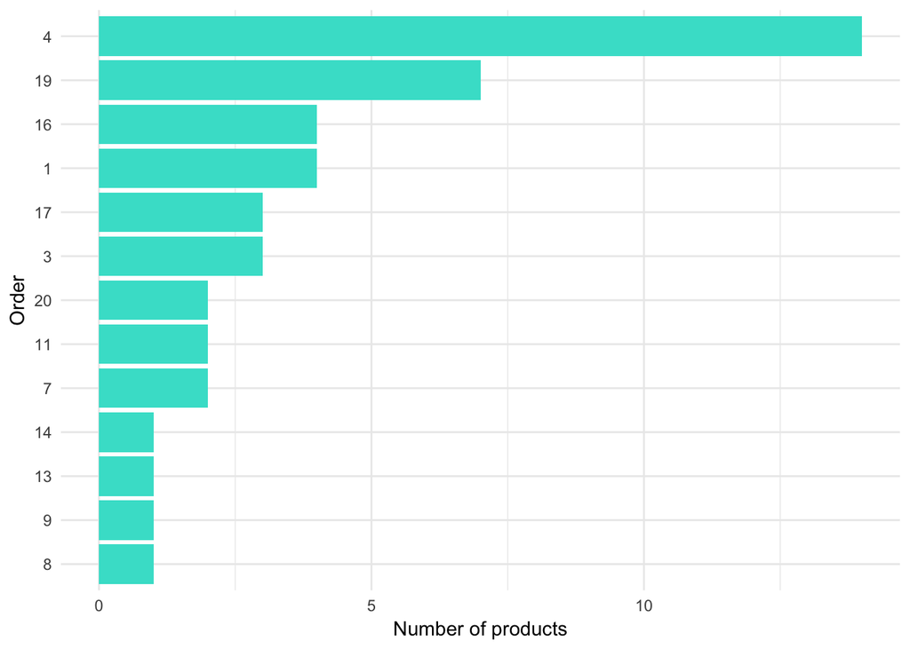

```r
last_prods_dpt %>%
  ggplot(aes(reorder(department_id, n, function(x) x),
        n)) +
    geom_bar(stat="identity", fill='turquoise') +
    scale_y_continuous(label=scales::comma) +
    coord_flip() +
    xlab("Order") +
    ylab("Number of products") +
    theme_minimal()
```

Now we can see that, the last added products in a cart come mainly from the 4th department, as well as many from the 19th. These correspondingly being *Produce (Fruits & Vegetables)* and *Snacks*. The first is by far the most common department, not in the amount of different products they have, but the one from which the most ordered products are from. Therefore, it is not uncommon for it to also be the most relevant here. Our interest falls on the latter though. As we suggested, many products which are last added to a cart are whims.

**Actions** $\to$ Analysing the average number of products that each client usually has in his/her basket we could start doing recommendations for snacks as the number of items in the current purchase cart is getting closer to its usual maximum.

**Reordered**

Finally, we can analyse if this products are less reordered than the rest of products in the basket. Therefore, we’ll calculate the ratio of reordered products which have been added last to an order and we’ll compare it to the general ratio for these users.

```r
last_prods_reord_txt <- "
  SELECT reordered, COUNT(1) as n
  FROM
    (SELECT *
    FROM (SELECT order_id
          ,   LAST_VALUE(add_to_cart_order)  OVER(partition by order_id ORDER BY order_id) AS nmax
          FROM order_products__prior_tbl
          WHERE order_id <= 50) a
    GROUP BY order_id, nmax
    ORDER BY order_id) aa
      LEFT JOIN order_products__prior_tbl AS b
      ON aa.nmax=b.add_to_cart_order
  WHERE aa.order_id=b.order_id
  GROUP BY reordered
  ORDER BY n DESC
"

(last_prods_reord <-
  dbGetQuery(sc, last_prods_reord_txt))
```

```
##   reordered  n
## 1         0 26
## 2         1 19
```

```r
#ratio
round(last_prods_reord[2,2]/sum(last_prods_reord[1:2,2]),3)
```

```
## [1] 0.422
```

```r
order_products__prior %>%
  filter(order_id <= 50) %>%
  select(reordered) %>%
  group_by(reordered) %>%
  summarise(n =n()) %>%
  collect
```

```
## # A tibble: 2 x 2
##   reordered     n
##       <int> <dbl>
## 1         0   176
## 2         1   228
```

```r
#ratio
round(228/(228+176), 3)
```

```
## [1] 0.564
```

As we can see, the latter added products are less frequently reordered products from previous purchases, which would be consistent with our first hypothesis that they are usually not planned beforehand but instead, have been added more impulsively.

## Regular consumers

In this case we are interested in analysing if a person who buys everyday repeats products, and if their consecutive purchases are completely different or clearly structured.

Both cases would make sense, as a person who buys regularly, in the most extreme case, everyday for the correponding meals; will have very different orders from one day to another if he/she’s keeping a balanced diet. At the same time, his/her orders will become more systematic and will present a clear structure, which will get plotted on the order reordered products are ticked.

First, we present two simple queries which will bring us to the complete one resulting from their union.

```r
#When are reordered products added to the cart
dbGetQuery(sc,
"SELECT order_id
,   add_to_cart_order
,   SUM(reordered) OVER (PARTITION by order_id ORDER BY add_to_cart_order) AS n_reordered_prod
FROM order_products__prior_tbl
WHERE order_id < 10
")
```

```
##    order_id add_to_cart_order n_reordered_prod
## 1         7                 1                0
## 2         7                 2                0
## 3         8                 1                1
## 4         9                 1                0
## 5         9                 2                1
## 6         9                 3                1
## 7         9                 4                2
## 8         9                 5                3
## 9         9                 6                4
## 10        9                 7                5
## 11        9                 8                6
## 12        9                 9                6
## 13        9                10                7
## 14        9                11                7
```

[output cut: 63 more lines]

```r
#Who are regular users
dbGetQuery(sc,
"SELECT order_id
FROM orders_tbl
WHERE days_since_prior_order < 4
LIMIT 30
")
```

```
##    order_id
## 1   2295261
## 2   1901567
## 3   2557754
## 4   3321109
## 5   3120740
## 6    369015
## 7   1366559
## 8   2345592
## 9   1681401
## 10  2373492
## 11  2660930
## 12  2148135
## 13  3106101
## 14   157550
```

[output cut: 16 more lines]

*When do frequent users add reordered products to the cart*

That is, in which order do users who buy on a regular basis (who shop at least twice a week) add reordered products into their carts.

```r
dbGetQuery(sc,
"SELECT b.order_id
,   product_id
,   add_to_cart_order
,   SUM(reordered) OVER (PARTITION by b.order_id ORDER BY add_to_cart_order) AS n_reordered_prod
,   days_since_prior_order
FROM (SELECT order_id, days_since_prior_order
      FROM orders_tbl
      WHERE days_since_prior_order < 4
      LIMIT 30) a
  LEFT JOIN order_products__prior_tbl b
  ON a.order_id=b.order_id
WHERE b.order_id IS NOT NULL
")
```

```
##     order_id product_id add_to_cart_order n_reordered_prod
## 1     369015      47272                 1                1
## 2     369015      37999                 2                2
## 3     369015      21137                 3                3
## 4     369015      12196                 4                4
## 5     369015      23712                 5                5
## 6    1366559      29509                 1                1
## 7    1366559      23360                 2                1
## 8    1366559      23803                 3                2
## 9    1901567      47766                 1                1
## 10   1901567      32792                 2                2
## 11   1901567      20574                 3                3
## 12   1901567       7781                 4                3
## 13   1901567      28874                 5                3
## 14   2148135      38760                 1                1
```

[output cut: 359 more lines]

As we can see, there are some consumers who do not reorder the same products from one day to another. They might be alternating their carts to finish the week, as we suggested, on a balanced diet.

But, on the other hand, most of this users rebuy exactly the same things, and it is precisely these reordered products the ones which are first added to their carts. This corresponds to a very structured shopper who has a clear system and knows exactly what he/she’s going to add to the cart before even opening the app. At the end of their shopping lists they might be adding some extra products which they were not predicting or that have been suggested for them, as we saw happens with the latter added items.

**Actions** $\to$ As this confirms the analysis that we made in the previous section, we should focus on starting to recommend snacks at that point of the shopping cart where the user is almost getting to the end of his order.

Finally, we might be interested in analysing which products are more frequently bought by this consumers’ group.

**Regular consumers most ordered products**

```r
regular_consumer_txt <- "
SELECT ab.product_id
,   n_orders
,   product_name
FROM (
    SELECT product_id
    ,   COUNT(1) AS n_orders
    FROM (SELECT order_id
          FROM orders_tbl
          WHERE days_since_prior_order < 4) a
      LEFT JOIN order_products__prior_tbl b
      ON a.order_id = b.order_id
    GROUP BY product_id
    ORDER BY n_orders DESC
    LIMIT 30) ab
LEFT JOIN (
    SELECT product_id
    ,   product_name
    FROM products_tbl) c
ON ab.product_id = c.product_id
"

(regular_consumer <-
  dbGetQuery(sc, regular_consumer_txt))
```

```
##    product_id n_orders                         product_name
## 1       24852    61811                               Banana
## 2       13176    61691               Bag of Organic Bananas
## 3       21137    43206                 Organic Strawberries
## 4       47209    34964                 Organic Hass Avocado
## 5       21903    32437                 Organic Baby Spinach
## 6       27966    24927                  Organic Raspberries
## 7       47766    22012                      Organic Avocado
## 8       27845    21728                   Organic Whole Milk
## 9       26209    20946                                Limes
## 10      47626    20284                          Large Lemon
## 11         NA    19378                                 <NA>
## 12      16797    19254                         Strawberries
## 13      22935    18894                 Organic Yellow Onion
## 14      24964    17356                       Organic Garlic
```

[output cut: 16 more lines]

As we can see, again, their most ordered products do not difer from those most generally ordered. In fact, we could think that these most regular consumers are the ones that end up determining which are the most ordered products among the whole dataset.

# Recommender and Predictions

First of all we’ll create a rating for the products. In this sense, we’ll give between zero and ten points to each product the 10 first consumers have in their basket. Thus, we won’t be given a single value for all of them as the general recommendation for snacks that we suggested before did, but the next product will be uniquely thought for each one of them.

*Note*: we are only working on the first ten users but we can extend this analysis to all of them.

```r
order_products__prior %>%
  select(order_id, product_id) %>%
  left_join(orders, by="order_id") %>%
  filter(user_id <= 10) %>% #d'entrada ho fem només per a 10 usuaris, es recomana anar augmentant la mida poc a poc
  select(product_id, user_id) %>%
  group_by(user_id, product_id) %>%
  summarise(rating = n()) %>%
  rename(user = user_id) %>%
  mutate(item=product_id) %>%
  select(user, item, rating) ->
  user_item_rating

user_item_rating
```

```
## # Source:   lazy query [?? x 3]
## # Database: spark_connection
## # Groups:   user
##     user  item rating
##    <int> <int>  <dbl>
##  1     7  4920      7
##  2     7 11520      1
##  3     7 27344      1
##  4     7 47272      4
##  5     7 23712      2
##  6     3 17668      5
##  7     2 47209      8
##  8     2 14553      1
##  9     2 47553      1
## 10     2 18961      1
## # ... with 451 more rows
```

To continue, we’ll try out a simple *Alternating Least Squares* model to adjust the data.

```r
(explicit_model <- ml_als_factorization( user_item_rating, iter.max = 5, regularization.parameter = 0.01))
```

```
## $item.factors
##        id          V1          V2           V3          V4          V5
## 1      23 -0.03568562  0.48578790 -0.108990766 0.067007884  0.45576102
## 2      79 -0.03568562  0.48578790 -0.108990766 0.067007884  0.45576102
## 3     196 -0.57107013  0.36275500  0.926665127 0.097481996  2.58862448
## 4     248  0.06223182  0.24111231  0.065591149 0.330969155  0.49301457
## 5     260  1.54569006 -0.42426747 -0.452675998 0.023766426 -0.19499090
## 6     274 -0.09235497 -0.60935247 -0.073391385 0.179196969 -0.16272146
## 7     311 -0.39988753 -0.24365783 -0.407742679 0.208207607  0.17467330
## 8     481 -0.79977506 -0.48731565 -0.815485358 0.416415215  0.34934661
## 9     519 -0.18470994 -1.21870494 -0.146782771 0.358393937 -0.32544291
## 10    651 -0.03790793 -0.28363132  0.191145673 0.393591225 -0.02184282
## 11   1005  0.06223182  0.24111231  0.065591149 0.330969155  0.49301457
## 12   1200  0.06728055  0.21860844 -0.424716592 0.193160683 -0.15830821
## 13   1529  2.21084619 -0.78122121 -0.540700436 0.267759591 -0.29469123
```

[output cut: 854 more lines]

In the resulting matrices we have the principal axes that descibe each dimension. The `$user.factors` matrix is square while we have `$item.factors` for each of the products that have been taken into account.

As we are applying a simple factorization method, we’ll define our data matrix as:

$$A_{nxm} = U_{nxp} (V^{T})_{pxm}$$

where $U$ defines the individuals, in our case the consumers; and $V$ defines variables, in our case the items.

The original values are directly related to the weights each product and customer has on the definition of each dimension, while the final values in $A$ will correspond to a second more accurate rating of the products.

**A Matrix**

```r
U <- as.matrix(explicit_model$user.factors[,-1])
V <- as.matrix(explicit_model$item.factors[,-1])
A <- U%*%t(V)
```

One approach to predict which one will be the next product added by a consumer could be taking for each one of them that one item which has the highest final rating.

Below, we suggest one way to determine the indexes of these products inside the matrix `A`.

```r
#indexes where the maximum value is found
i_max <- apply(A,1,max)
ls <- list()
for(i in 1:nrow(A)){
  ls[[i]] <- which(A[i,]==i_max[i])
}
```

Then, for each user, we can obtain which products this correspond to.

```r
ls_prods <- list()
for(i in 1:length(ls)){
  ls_prods[[i]] <- vector()
  for(j in 1:length(ls[[i]])){
    ls_prods[[i]] <- c(ls_prods[[i]], explicit_model$item.factors[ls[[i]][j],1])
  }
}
ls_prods
```

```
## [[1]]
## [1]   196 12427
##
## [[2]]
## [1] 32792
##
## [[3]]
## [1] 39190
##
## [[4]]
## [1]   196 12427
##
## [[5]]
## [1] 26604
##
## [[6]]
## [1] 32792
##
## [[7]]
## [1] 40852
##
## [[8]]
## [1] 40852
##
## [[9]]
## [1] 27973
##
## [[10]]
## [1] 28535 46979
```

Thus, if we want to know, which item will be most likely chosen the next time by one particular user we just have to look up his/her position in the list.

With this we would obtain the product with which each customer is most satisfied but that doesn’t give us a concrete idea on which new product to recommend him. To attain this purpose we could do a simple *PCA* on the complete dataset to determine how each one of the variables affects final decisions, detect clusters and see graphically where a customer is located and which products are in his/her vicinity, both if he has bought them in the past or not. This would give us much more information to play with when determining if a new product is something for him or not, by just looking where this new product falls on the map and where the customer stands.